# 15｜密度分群與機率模型

對應 `10_密度分群與機率模型.md`（主教材 Ch.8 pp.265–282）。課堂操作約 25 分鐘。目標：讀懂 DBSCAN 的核心／邊界／雜訊、GMM 的 EM 兩步、用密度分數與 AIC／BIC 做選擇，並接回 PCA 重建誤差找異常。

## 來源與改編界線

- [ageron/handson-mlp / 08_unsupervised_learning.ipynb](https://github.com/ageron/handson-mlp/blob/47eba45aacc85feae51ba7db68dd1ca66cb25e0a/08_unsupervised_learning.ipynb)：DBSCAN、Gaussian Mixtures、EM、covariance_type、密度異常、AIC／BIC、Bayesian GMM
- [leonjyentub/MachineLearning2025 / 05_GMM_from_scratch.py](https://github.com/leonjyentub/MachineLearning2025/blob/3da2cb56b9efd17d7cd34602589f392554b40603/05_GMM_from_scratch.py)：手寫 E-step／M-step 與責任值
- [leonjyentub/MachineLearning2025 / 05_DBSCAN.ipynb](https://github.com/leonjyentub/MachineLearning2025/blob/3da2cb56b9efd17d7cd34602589f392554b40603/05_DBSCAN.ipynb)：DBSCAN 參數與雜訊
- [leonjyentub/MachineLearning2025 / 05_Clustering_DBSCAN.py](https://github.com/leonjyentub/MachineLearning2025/blob/3da2cb56b9efd17d7cd34602589f392554b40603/05_Clustering_DBSCAN.py)：eps／min_samples 效果

**本課程修改／補充：** DBSCAN 用 moons 比較 eps；驗算投影片一維鄰域手算（`[0,.1,.2,.4,2.0]`）；DBSCAN 無原生 predict，以核心點最近鄰延伸並拒絕過遠點；GMM 手寫 E／M 一步並驗算投影片軟指派活動；`covariance_type` full／tied／spherical 比較；`score_samples` 百分位當異常閾值；AIC／BIC 驗算投影片數例（A：p=5,ℓ=−100；B：p=8,ℓ=−96）並在真實資料上跑；最後用 PCA 重建誤差當另一種異常分數。

來源固定至上述 commit；原檔保留於 `../upstream/`，逐檔 SHA-256 見 `../upstream/manifest.json`。Géron 程式依 Apache-2.0 改編，授權原文保留；教師程式保留原作者歸屬。儲存格索引從 0 起算。圖表與數值是本 Notebook 重跑結果，不能直接當成書中成效。

從第一格依序執行；各本可獨立重跑。Python 環境與資料準備見 操作說明。

```python
import numpy as np
import pandas as pd
import matplotlib.pyplot as plt
from mlcourse.common import ROOT, DATA, OUT, SEED, FAST, setup, savefig, report, data_path
setup()
```

```
{'profile': 'fast',
 'seed': 42,
 'data': '/Users/leonjye/Documents/MacProject/MLCourse2026/programs/data'}
```

## 1. DBSCAN：核心點把密集區連成一群

`labels_` 中的 `-1` 是雜訊；`core_sample_indices_` 是核心點。改 `eps` 會讓同一資料從破碎變連續（教材圖 8-13）。

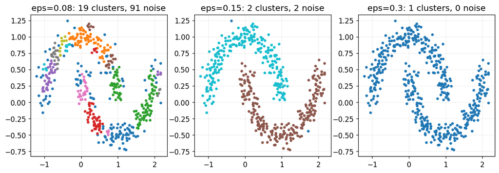

| eps | clusters | noise | core_points |
| --- | --- | --- | --- |
| 0.08 | 19 | 91 | 281 |
| 0.15 | 2 | 2 | 477 |
| 0.30 | 1 | 0 | 500 |

```python
from sklearn.datasets import make_moons
from sklearn.cluster import DBSCAN
Xm, _ = make_moons(n_samples=500, noise=.10, random_state=SEED)
fig, axes = plt.subplots(1, 3, figsize=(13, 4))
rows = []
for ax, eps in zip(axes, [0.08, 0.15, 0.30]):
    db = DBSCAN(eps=eps, min_samples=5).fit(Xm)
    n_clusters = len(set(db.labels_[db.labels_ != -1]))
    ax.scatter(Xm[:, 0], Xm[:, 1], c=db.labels_, cmap='tab10', s=10)
    ax.set_title(f'eps={eps}: {n_clusters} clusters, {np.sum(db.labels_ == -1)} noise')
    rows.append({'eps': eps, 'clusters': n_clusters, 'noise': int(np.sum(db.labels_ == -1)),
                 'core_points': len(db.core_sample_indices_)})
savefig('15_dbscan_eps')
pd.DataFrame(rows).set_index('eps')
```

## 2. 手算驗算：誰是核心，誰是雜訊？

對應投影片活動。一維點 `[0, .1, .2, .4, 2.0]`，`eps=.21`、`min_samples=3`（鄰域含自己）。

```python
pts = np.array([0., .1, .2, .4, 2.0]); eps = .21
neigh = (np.abs(pts[:, None] - pts[None]) <= eps).sum(axis=1)
assert neigh.tolist() == [3, 3, 4, 2, 1]
def classify(min_samples):
    core = neigh >= min_samples
    kind = []
    for i in range(len(pts)):
        if core[i]:
            kind.append('core')
        elif np.any(core & (np.abs(pts - pts[i]) <= eps)):
            kind.append('border')
        else:
            kind.append('noise')
    return kind
k3, k4 = classify(3), classify(4)
assert k3 == ['core', 'core', 'core', 'border', 'noise']
assert k4 == ['border', 'border', 'core', 'border', 'noise']
pd.DataFrame({'point': pts, 'neighbors': neigh, 'min_samples=3': k3, 'min_samples=4': k4})
```

|  | point | neighbors | min_samples=3 | min_samples=4 |
| --- | --- | --- | --- | --- |
| 0 | 0.0 | 3 | core | border |
| 1 | 0.1 | 3 | core | border |
| 2 | 0.2 | 4 | core | core |
| 3 | 0.4 | 2 | border | border |
| 4 | 2.0 | 1 | noise | noise |

## 3. DBSCAN 沒有原生 predict：延伸要另訂規則

一種延伸是用核心點的最近鄰投票，並拒絕距離所有核心點都超過 `eps` 的新點（教材圖 8-14）。

```python
from sklearn.neighbors import KNeighborsClassifier
db = DBSCAN(eps=0.18, min_samples=5).fit(Xm)
core_mask = np.zeros(len(Xm), bool); core_mask[db.core_sample_indices_] = True
knn = KNeighborsClassifier(n_neighbors=5).fit(Xm[core_mask], db.labels_[core_mask])
from sklearn.neighbors import NearestNeighbors
nn = NearestNeighbors(n_neighbors=1).fit(Xm[core_mask])
new_pts = np.array([[0.0, 0.3], [1.0, -0.3], [2.5, 2.5]])   # 最後一點刻意很遠
dist, _ = nn.kneighbors(new_pts)
pred = knn.predict(new_pts)
pred = np.where(dist[:, 0] <= 0.18, pred, -1)               # 太遠 -> 拒絕
assert pred[-1] == -1 and np.all(pred[:2] != -1)
pd.DataFrame({'x': new_pts[:, 0], 'y': new_pts[:, 1], 'dist_to_core': dist[:, 0].round(3), 'assigned': pred})
```

|  | x | y | dist_to_core | assigned |
| --- | --- | --- | --- | --- |
| 0 | 0.0 | 0.3 | 0.015 | 0 |
| 1 | 1.0 | -0.3 | 0.037 | 0 |
| 2 | 2.5 | 2.5 | 1.937 | -1 |

## 4. GMM 與 EM：先選成分，再從該高斯取樣

`GaussianMixture` 同時給群邊界與密度等高線（教材圖 8-15）。`converged_`、`n_iter_` 顯示 EM 是否收斂。

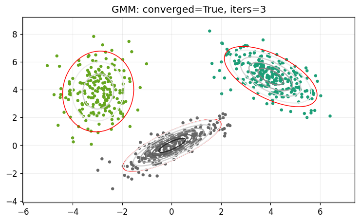

```
weights: [0.357 0.287 0.356]
```

```python
from sklearn.mixture import GaussianMixture
from matplotlib.patches import Ellipse
rng = np.random.default_rng(SEED)
G = np.vstack([rng.multivariate_normal([0, 0], [[1, .8], [.8, 1]], 250),
               rng.multivariate_normal([4, 5], [[1, -.6], [-.6, 1]], 250),
               rng.multivariate_normal([-3, 4], [[.5, 0], [0, 2]], 200)])
gm = GaussianMixture(n_components=3, n_init=10, covariance_type='full', random_state=SEED).fit(G)
xx, yy = np.meshgrid(np.linspace(G[:, 0].min() - 1, G[:, 0].max() + 1, 200),
                     np.linspace(G[:, 1].min() - 1, G[:, 1].max() + 1, 200))
dens = np.exp(gm.score_samples(np.c_[xx.ravel(), yy.ravel()])).reshape(xx.shape)
plt.contour(xx, yy, dens, levels=8, cmap='Greys')
plt.scatter(G[:, 0], G[:, 1], c=gm.predict(G), cmap='Dark2', s=10)
for k in range(3):
    v, w = np.linalg.eigh(gm.covariances_[k])
    ang = np.degrees(np.arctan2(w[1, 0], w[0, 0]))
    plt.gca().add_patch(Ellipse(gm.means_[k], 2 * 2 * np.sqrt(v[0]), 2 * 2 * np.sqrt(v[1]),
                                angle=ang, fill=False, edgecolor='red'))
plt.title(f'GMM: converged={gm.converged_}, iters={gm.n_iter_}')
savefig('15_gmm_ellipses')
print('weights:', np.round(gm.weights_, 3))
```

## 5. 手算驗算：軟指派與一次更新

對應投影片活動。E-step：兩成分權重皆 `.5`，某點在兩成分下的密度為 `.2` 與 `.05`。M-step：資料 `[0,2]`，成分 A 的責任值 `[.8, .2]`。

```python
w = np.array([.5, .5]); dens_pt = np.array([.2, .05])
resp = w * dens_pt / np.sum(w * dens_pt)
assert np.allclose(resp, [.8, .2])

data = np.array([0., 2.]); rA = np.array([.8, .2])
NA = rA.sum(); piA = NA / len(data)
muA = np.sum(rA * data) / NA
varA = np.sum(rA * (data - muA) ** 2) / NA
assert np.isclose(NA, 1.0) and np.isclose(piA, .5) and np.isclose(muA, .4) and np.isclose(varA, .64)
pd.Series({'E_step_responsibilities': resp.tolist(), 'N_A': NA, 'new_weight_A': piA,
           'new_mean_A': muA, 'new_variance_A': varA})
```

```
E_step_responsibilities    [0.8, 0.2]
N_A                               1.0
new_weight_A                      0.5
new_mean_A                        0.4
new_variance_A                   0.64
dtype: object
```

## 6. 限制共變異形狀：full、tied、spherical

限制形狀可降低參數量與過擬合風險，但也可能切出不符合資料的群（教材圖 8-16）。

```python
rows = []
for ct in ['full', 'tied', 'spherical', 'diag']:
    g = GaussianMixture(n_components=3, n_init=5, covariance_type=ct, random_state=SEED).fit(G)
    rows.append({'covariance_type': ct, 'n_parameters': g._n_parameters(),
                 'mean_log_likelihood': g.score(G), 'BIC': g.bic(G)})
cov_table = pd.DataFrame(rows).set_index('covariance_type')
assert cov_table.loc['spherical', 'n_parameters'] < cov_table.loc['full', 'n_parameters']
cov_table
```

| covariance_type | n_parameters | mean_log_likelihood | BIC |
| --- | --- | --- | --- |
| full | 17 | -3.649635 | 5220.856699 |
| tied | 11 | -3.957775 | 5612.947227 |
| spherical | 11 | -3.978047 | 5641.328079 |
| diag | 14 | -3.912858 | 5569.716311 |

## 7. 密度異常與 AIC／BIC

`score_samples` 給每點的對數密度；取低百分位當閾值標出異常（教材圖 8-17）。AIC／BIC 對複雜度的懲罰不同，可能給不同答案。

```
AIC prefers B (208 < 210); BIC prefers A (223.0 < 228.8)
```

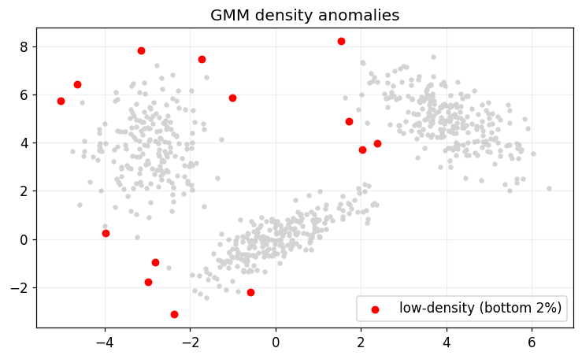

| n_components | AIC | BIC |
| --- | --- | --- |
| 1 | 6701.6 | 6724.3 |
| 2 | 5812.8 | 5862.9 |
| 3 | 5143.5 | 5220.9 |
| 4 | 5147.5 | 5252.2 |
| 5 | 5159.4 | 5291.4 |
| 6 | 5167.5 | 5326.8 |
| 7 | 5173.5 | 5360.1 |

```python
# 投影片數例：A p=5, loglik=-100；B p=8, loglik=-96；m=100
m = 100
aic = lambda p, ll: 2 * p - 2 * ll
bic = lambda p, ll: p * np.log(m) - 2 * ll
assert aic(5, -100) == 210 and aic(8, -96) == 208
assert np.isclose(bic(5, -100), 223.02585) and np.isclose(bic(8, -96), 228.84136)
print('AIC prefers B (208 < 210); BIC prefers A (223.0 < 228.8)')

# 真實資料：低密度點當異常
log_density = gm.score_samples(G)
threshold = np.percentile(log_density, 2)
flagged = log_density < threshold
plt.scatter(G[:, 0], G[:, 1], c='lightgray', s=10)
plt.scatter(G[flagged, 0], G[flagged, 1], c='red', s=30, label='low-density (bottom 2%)')
plt.legend(); plt.title('GMM density anomalies')
savefig('15_gmm_anomaly')

# 選成分數：AIC / BIC 曲線
ns = range(1, 8)
aics = [GaussianMixture(n, n_init=5, random_state=SEED).fit(G).aic(G) for n in ns]
bics = [GaussianMixture(n, n_init=5, random_state=SEED).fit(G).bic(G) for n in ns]
report('density_probabilistic', {'neighbor_counts': neigh.tolist(),
       'em_responsibilities': resp.tolist(), 'em_update_A': {'mean': muA, 'variance': varA},
       'aic_bic_worked_example': {'A': [aic(5, -100), bic(5, -100)], 'B': [aic(8, -96), bic(8, -96)]},
       'covariance_types': cov_table.to_dict(),
       'best_n_by_bic': int(list(ns)[int(np.argmin(bics))]), 'anomaly_threshold': float(threshold)})
pd.DataFrame({'n_components': list(ns), 'AIC': np.round(aics, 1), 'BIC': np.round(bics, 1)}).set_index('n_components')
```

## 8. 接回 PCA：用重建誤差找異常

在正常資料學到的低維子空間裡難以重建的點，重建誤差較高（教材 pp.280–281）。這是另一種分數，不是 GMM 密度。

```python
from sklearn.datasets import load_digits
from sklearn.model_selection import train_test_split
from sklearn.decomposition import PCA
digits = load_digits()
X8 = digits.data[digits.target == 8]                     # 只用數字 8 當「正常」
Xtr, Xval = train_test_split(X8, test_size=.3, random_state=SEED)
pca = PCA(n_components=12, random_state=SEED).fit(Xtr)
def recon_error(X):
    return np.mean((X - pca.inverse_transform(pca.transform(X))) ** 2, axis=1)
thr = np.percentile(recon_error(Xval), 95)
others = digits.data[digits.target != 8][:300]           # 非 8 應多半被標出
flag_rate_normal = float(np.mean(recon_error(Xval) > thr))
flag_rate_other = float(np.mean(recon_error(others) > thr))
assert flag_rate_other > flag_rate_normal
print(f'flag rate: held-out 8s = {flag_rate_normal:.2f}, non-8 digits = {flag_rate_other:.2f}')
```

```
flag rate: held-out 8s = 0.06, non-8 digits = 0.98
```

## 練習與參考答案

- 可以用非核心的邊界點把 DBSCAN 延伸到新點嗎？**不可，延伸應以核心點為準並拒絕過遠點。**
- 責任值與密度一樣嗎？**否，責任值是成分後驗、每列和為 1；密度是單位體積的量。**
- AIC 與 BIC 給不同答案時怎麼辦？**它們是相對選擇準則，不是正確率；BIC 對參數增加懲罰較重，需結合用途判斷。**
- 重建誤差一定能找到所有異常嗎？**否，若異常剛好落在保留的子空間內就偵測不到。**